# R Notebook

# Section 4.6 Choosing Final Tuning Parameters

```r
library(caret)
data(GermanCredit)
```

```r
GermanCredit <- GermanCredit[, -nearZeroVar(GermanCredit)]
GermanCredit$CheckingAccountStatus.lt.0 <- NULL
GermanCredit$SavingsAccountBonds.lt.100 <- NULL
GermanCredit$EmploymentDuration.lt.1 <- NULL
GermanCredit$EmploymentDuration.Unemployed <- NULL
GermanCredit$Personal.Male.Married.Widowed <- NULL
GermanCredit$Property.Unknown <- NULL
GermanCredit$Housing.ForFree <- NULL
```

Split the data into training (80%) and test sets (20%)

```r
set.seed(100)
inTrain <- createDataPartition(GermanCredit$Class, p = .8)[[1]]
GermanCreditTrain <- GermanCredit[ inTrain, ]
GermanCreditTest  <- GermanCredit[-inTrain, ]
```

The model fitting code shown in the computing section is fairly simplistic. For the text we estimate the tuning parameter grid up-front and pass it in explicitly. This generally is not needed, but was used here so that we could trim the cost values to a presentable range and to re-use later with different resampling methods.

```r
library(kernlab)
set.seed(231)
sigDist <- sigest(Class ~ ., data = GermanCreditTrain, frac = 1)
svmTuneGrid <- data.frame(sigma = as.vector(sigDist)[1], C = 2^(-2:7))
```

**Optional**: parallel processing can be used via the ‘do’ packages, such as doMC, doMPI etc. We used doMC (not on Windows) to speed up the computations.

**WARNING**: Be aware of how much memory is needed to parallel process. It can very quickly overwhelm the available hardware. We estimate the memory usage (VSIZE = total memory size) to be 2566M/core.

```r
library(doMC)
registerDoMC(4)

set.seed(1056)
svmFit <- train(Class ~ .,
                data = GermanCreditTrain,
                method = "svmRadial",
                preProc = c("center", "scale"),
                tuneGrid = svmTuneGrid,
                trControl = trainControl(method = "repeatedcv",
                                         repeats = 5,
                                         classProbs = TRUE))
```

**classProbs = TRUE** was added since the text was written.

Print the results

```r
svmFit
```

```
Support Vector Machines with Radial Basis Function Kernel

800 samples
 41 predictor
  2 classes: 'Bad', 'Good'

Pre-processing: centered (41), scaled (41)
Resampling: Cross-Validated (10 fold, repeated 5 times)
Summary of sample sizes: 720, 720, 720, 720, 720, 720, ...
Resampling results across tuning parameters:

  C       Accuracy  Kappa
    0.25  0.74475   0.3499435
    0.50  0.74925   0.3616706
    1.00  0.75150   0.3589289
    2.00  0.76125   0.3703041
    4.00  0.76250   0.3620893
    8.00  0.76175   0.3577653
   16.00  0.75700   0.3414921
   32.00  0.75275   0.3218237
   64.00  0.74450   0.2909504
  128.00  0.74700   0.3043005

Tuning parameter 'sigma' was held constant at a value of 0.008803212
Accuracy was used to select the optimal model using the largest value.
The final values used for the model were sigma = 0.008803212 and C = 4.
```

A line plot of the average performance. The ‘scales’ argument is actually an argument to xyplot that converts the x-axis to log-2 units.

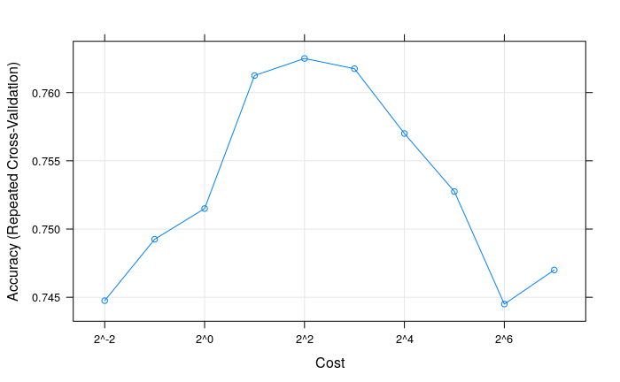

```r
plot(svmFit, scales = list(x = list(log = 2)))
```

Test set predictions

```r
predictedClasses <- predict(svmFit, GermanCreditTest)
str(predictedClasses)
```

```
 Factor w/ 2 levels "Bad","Good": 2 2 2 2 2 2 2 2 1 2 ...
```

Use the “type” option to get class probabilities

```r
predictedProbs <- predict(svmFit, newdata = GermanCreditTest, type = "prob")
head(predictedProbs)
```

|  | Bad | Good |
| --- | --- | --- |
| 1 | 0.37436169 | 0.6256383 |
| 2 | 0.07604999 | 0.9239500 |
| 3 | 0.09014613 | 0.9098539 |
| 4 | 0.26828662 | 0.7317134 |
| 5 | 0.34200640 | 0.6579936 |
| 6 | 0.07073846 | 0.9292615 |

Fit the same model using different resampling methods. The main syntax change is the control object.

```r
set.seed(1056)
svmFit10CV <- train(Class ~ .,
                    data = GermanCreditTrain,
                    method = "svmRadial",
                    preProc = c("center", "scale"),
                    tuneGrid = svmTuneGrid,
                    trControl = trainControl(method = "cv", number = 10))
svmFit10CV
```

```
Support Vector Machines with Radial Basis Function Kernel

800 samples
 41 predictor
  2 classes: 'Bad', 'Good'

Pre-processing: centered (41), scaled (41)
Resampling: Cross-Validated (10 fold)
Summary of sample sizes: 720, 720, 720, 720, 720, 720, ...
Resampling results across tuning parameters:

  C       Accuracy  Kappa
    0.25  0.70000   0.00000000
    0.50  0.70375   0.02673692
    1.00  0.74250   0.24803618
    2.00  0.76125   0.36244041
    4.00  0.76875   0.40085135
    8.00  0.75875   0.39195339
   16.00  0.74875   0.38706775
   32.00  0.74125   0.37868297
   64.00  0.72750   0.35749038
  128.00  0.72750   0.35697217

Tuning parameter 'sigma' was held constant at a value of 0.008803212
Accuracy was used to select the optimal model using the largest value.
The final values used for the model were sigma = 0.008803212 and C = 4.
```

```r
set.seed(1056)
svmFitLOO <- train(Class ~ .,
                   data = GermanCreditTrain,
                   method = "svmRadial",
                   preProc = c("center", "scale"),
                   tuneGrid = svmTuneGrid,
                   trControl = trainControl(method = "LOOCV"),verboseIter= TRUE)
svmFitLOO
```

```
Support Vector Machines with Radial Basis Function Kernel

800 samples
 41 predictor
  2 classes: 'Bad', 'Good'

Pre-processing: centered (41), scaled (41)
Resampling: Leave-One-Out Cross-Validation
Summary of sample sizes: 799, 799, 799, 799, 799, 799, ...
Resampling results across tuning parameters:

  C       Accuracy  Kappa
    0.25  0.70000   0.0000000
    0.50  0.70375   0.0270936
    1.00  0.74750   0.2723343
    2.00  0.76875   0.3825100
    4.00  0.77125   0.4066148
    8.00  0.76000   0.3954660
   16.00  0.74875   0.3819188
   32.00  0.74125   0.3817204
   64.00  0.73750   0.3779621
  128.00  0.73625   0.3772137

Tuning parameter 'sigma' was held constant at a value of 0.008803212
Accuracy was used to select the optimal model using the largest value.
The final values used for the model were sigma = 0.008803212 and C = 4.
```

```r
set.seed(1056)
svmFitLGO <- train(Class ~ .,
                   data = GermanCreditTrain,
                   method = "svmRadial",
                   preProc = c("center", "scale"),
                   tuneGrid = svmTuneGrid,
                   trControl = trainControl(method = "LGOCV",
                                            number = 50,
                                            p = .8))
```

```r
set.seed(1056)
svmFitBoot <- train(Class ~ .,
                    data = GermanCreditTrain,
                    method = "svmRadial",
                    preProc = c("center", "scale"),
                    tuneGrid = svmTuneGrid,
                    trControl = trainControl(method = "boot", number = 50))
svmFitBoot
```

```
Support Vector Machines with Radial Basis Function Kernel

800 samples
 41 predictor
  2 classes: 'Bad', 'Good'

Pre-processing: centered (41), scaled (41)
Resampling: Bootstrapped (50 reps)
Summary of sample sizes: 800, 800, 800, 800, 800, 800, ...
Resampling results across tuning parameters:

  C       Accuracy   Kappa
    0.25  0.7025274  0.009192606
    0.50  0.7187371  0.127518985
    1.00  0.7391829  0.279620677
    2.00  0.7439334  0.332892149
    4.00  0.7477073  0.361330917
    8.00  0.7453639  0.367454456
   16.00  0.7382141  0.360861750
   32.00  0.7261412  0.339716466
   64.00  0.7220177  0.332807598
  128.00  0.7179844  0.325543243

Tuning parameter 'sigma' was held constant at a value of 0.008803212
Accuracy was used to select the optimal model using the largest value.
The final values used for the model were sigma = 0.008803212 and C = 4.
```

```r
set.seed(1056)
svmFitBoot632 <- train(Class ~ .,
                       data = GermanCreditTrain,
                       method = "svmRadial",
                       preProc = c("center", "scale"),
                       tuneGrid = svmTuneGrid,
                       trControl = trainControl(method = "boot632",
                                                number = 50))
svmFitBoot632
```

[output not shown]